# eda_irysy slides

## Co kryją płatki i kielichy? – Analiza zbioru Iris 🌸

## O Danych

Zbiór danych zawiera informacje o trzech gatunkach irysów: Iris setosa, Iris versicolor, i Iris virginica.

Dane obejmują pomiary czterech cech: długość i szerokość działki kielicha oraz długość i szerokość płatka.

Każdy wiersz w zbiorze danych reprezentuje pojedynczy kwiat, a wartości pomiarów są podane w centymetrach.

Zbiór składa się z 150 próbek, po 50 dla każdego gatunku, i jest szeroko stosowany jako podstawowy zbiór danych do testowania algorytmów klasyfikacji oraz w nauce o danych i uczeniu maszynowym.

Kolumny:

- **długość kielicha (sepal length)** - Długość kielicha w cm
- **szerokość kielicha (sepal width)** - Szerokość kielicha w cm
- **długość płatka (petal length)** - Długość płatka w cm
- **szerokość płatka (petal width)** - Szerokość płatka w cm
- **klasa (class)** - Klasa irysa (setosa, versicolor, virginica)

# EDA - Eksploracyjna analiza danych dotycząca irysów

## Krok 1 - Ogólny przegląd danych

### Pokazujemy 10 losowych rekordów

|  | długość kielicha (sepal length) | szerokość kielicha (sepal width) | długość płatka (petal length) | szerokość płatka (petal width) | klasa (class) |
| --- | --- | --- | --- | --- | --- |
| 31 | 5.4 | 3.4 | 1.5 | 0.4 | Iris-setosa |
| 71 | 6.1 | 2.8 | 4.0 | 1.3 | Iris-versicolor |
| 45 | 4.8 | 3.0 | 1.4 | 0.3 | Iris-setosa |
| 73 | 6.1 | 2.8 | 4.7 | 1.2 | Iris-versicolor |
| 68 | 6.2 | 2.2 | 4.5 | 1.5 | Iris-versicolor |
| 125 | 7.2 | 3.2 | 6.0 | 1.8 | Iris-virginica |
| 99 | 5.7 | 2.8 | 4.1 | 1.3 | Iris-versicolor |
| 7 | 5.0 | 3.4 | 1.5 | 0.2 | Iris-setosa |
| 22 | 4.6 | 3.6 | 1.0 | 0.2 | Iris-setosa |
| 26 | 5.0 | 3.4 | 1.6 | 0.4 | Iris-setosa |

### Informacje o kolumnach

```
<class 'pandas.core.frame.DataFrame'>
RangeIndex: 150 entries, 0 to 149
Data columns (total 5 columns):
 #   Column                            Non-Null Count  Dtype
---  ------                            --------------  -----
 0   długość kielicha (sepal length)   150 non-null    float64
 1   szerokość kielicha (sepal width)  150 non-null    float64
 2   długość płatka (petal length)     150 non-null    float64
 3   szerokość płatka (petal width)    150 non-null    float64
 4   klasa (class)                     150 non-null    object
dtypes: float64(4), object(1)
memory usage: 6.0+ KB
```

### Wartości unikatowe dla kolumn

```
długość kielicha (sepal length)     35
szerokość kielicha (sepal width)    23
długość płatka (petal length)       43
szerokość płatka (petal width)      22
klasa (class)                        3
dtype: int64
```

### Wartości dla poszczególnej klasy Irysa

```
klasa (class)
Iris-setosa        50
Iris-versicolor    50
Iris-virginica     50
Name: count, dtype: int64
```

### Wnioski

1. Niewątpliwie mamy do czynienia z kwiatami.
2. Mamy **150** rekordów, **3** klasy [Irysa](https://www.youtube.com/watch?v=NdYWuo9OFAw): [Setosa](https://upload.wikimedia.org/wikipedia/commons/a/a7/Irissetosa1.jpg), [Versicolor](https://sklep.trawyibyliny.eu/media/products/abf0a0e9b7780dab7cb5cd51c6340337/images/thumbnail/large_iris-versicolror.jpg?lm=1703869863) oraz [Virginica](https://encrypted-tbn0.gstatic.com/images?q=tbn:ANd9GcRy1muCi8NSQ8GBRdOlXGj6wTuvarw_uxOFQA&s). **50** rekordów dla każdej klasy.
3. Będziemy analizować długość i szerokość kielicha oraz długość i szerokość płatka dla 3 klas irysów.
4. Mamy **5** kolumn. **4** kolumny zawierają dane liczbowe. **1** kolumna zawiera tekst - nazwę klasy.

## Krok 2 - Analiza brakujących wartości

### Czy mamy jakieś brakujące wartości?

```
długość kielicha (sepal length)     0
szerokość kielicha (sepal width)    0
długość płatka (petal length)       0
szerokość płatka (petal width)      0
klasa (class)                       0
dtype: int64
```

### Czy zostały wykonane identyczne pomiary?

|  | długość kielicha (sepal length) | szerokość kielicha (sepal width) | długość płatka (petal length) | szerokość płatka (petal width) | klasa (class) |
| --- | --- | --- | --- | --- | --- |
| 34 | 4.9 | 3.1 | 1.5 | 0.1 | Iris-setosa |
| 37 | 4.9 | 3.1 | 1.5 | 0.1 | Iris-setosa |
| 142 | 5.8 | 2.7 | 5.1 | 1.9 | Iris-virginica |

### Wnioski

1. Nie ma brakujących wartości.
2. Warto jednak zaznaczyć, że w pomiarach zmierzono 3 idendyczne Irysy-Setosa oraz 2 identyczne Irysy-Virginica.

## Krok 3 - Analiza pojedyńczych zmiennych

### Histogramy bez uwzględnienia klasy Irysa

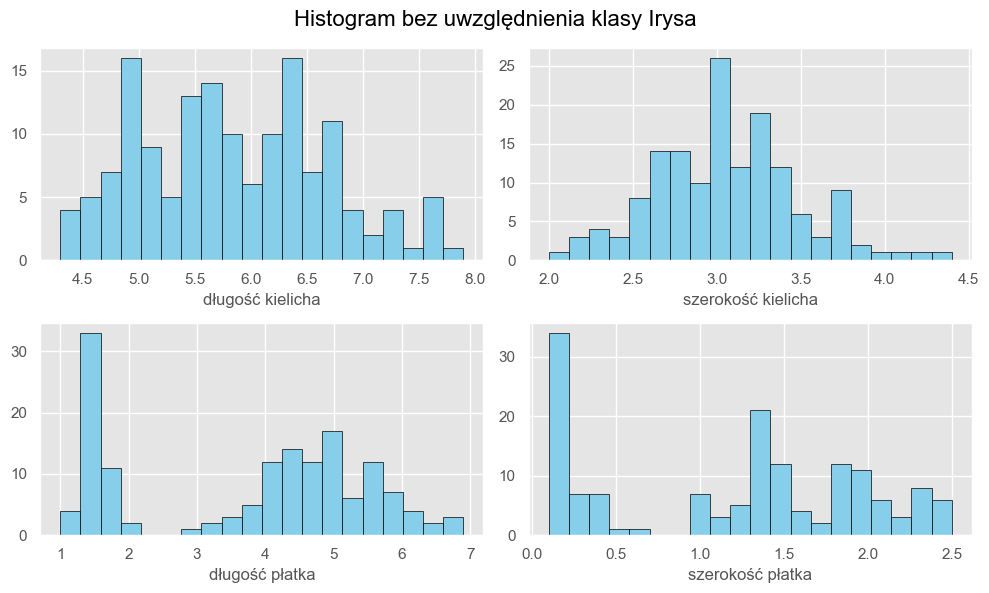

### Histogram dla **Iris-Setosa**

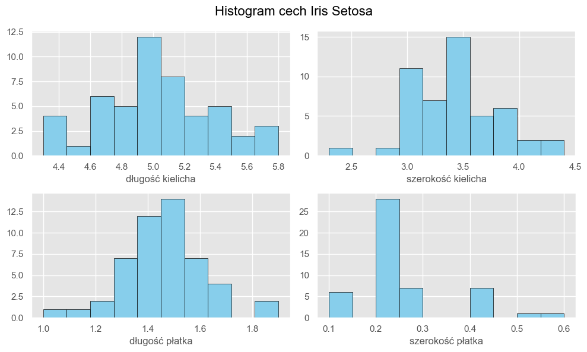

### Histogram dla **Iris-versicolor**

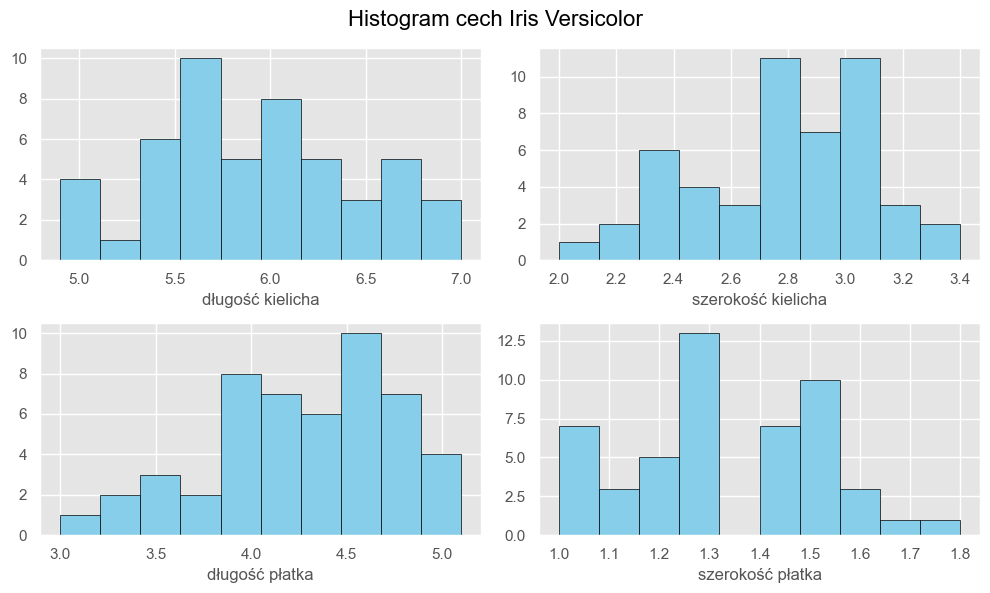

### Histogram dla **Iris-virginica**

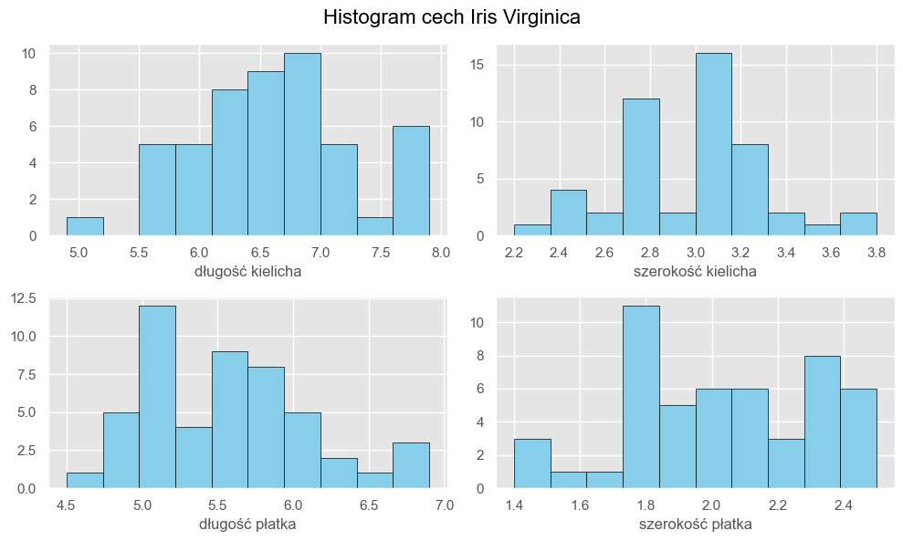

### Obliczenia i wykresy

#### Długość kielicha

|  | klasa (class) | długość kielicha (sepal length) mean | długość kielicha (sepal length) median | długość kielicha (sepal length) min | długość kielicha (sepal length) max |
| --- | --- | --- | --- | --- | --- |
| 0 | Iris-setosa | 5.01 | 5.00 | 4.30 | 5.80 |
| 1 | Iris-versicolor | 5.94 | 5.90 | 4.90 | 7.00 |
| 2 | Iris-virginica | 6.59 | 6.50 | 4.90 | 7.90 |

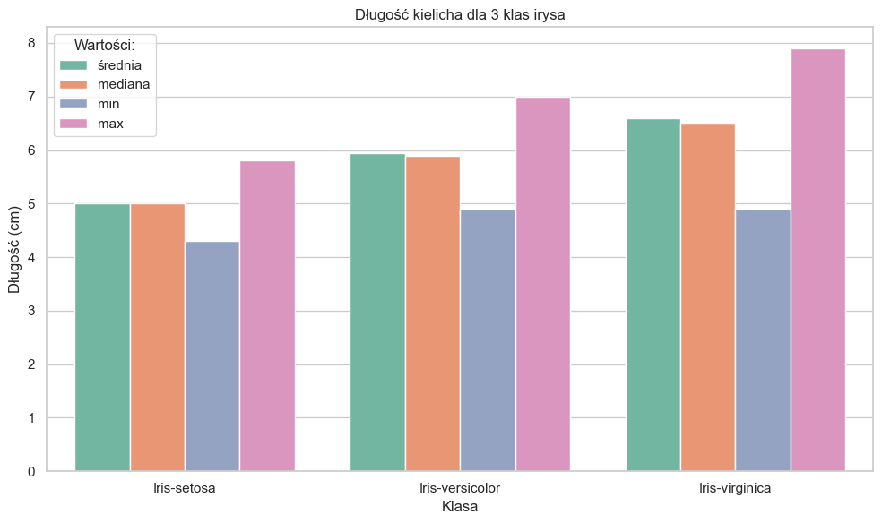

#### Szerokość Kielicha

|  | klasa (class) | szerokość kielicha (sepal width) mean | szerokość kielicha (sepal width) median | szerokość kielicha (sepal width) min | szerokość kielicha (sepal width) max |
| --- | --- | --- | --- | --- | --- |
| 0 | Iris-setosa | 3.42 | 3.40 | 2.30 | 4.40 |
| 1 | Iris-versicolor | 2.77 | 2.80 | 2.00 | 3.40 |
| 2 | Iris-virginica | 2.97 | 3.00 | 2.20 | 3.80 |

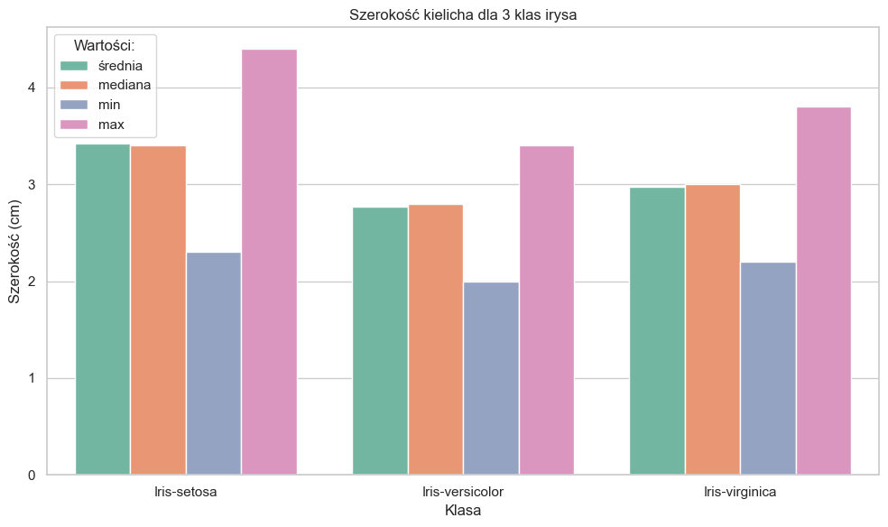

#### Długość płatka

|  | klasa (class) | długość płatka (petal length) mean | długość płatka (petal length) median | długość płatka (petal length) min | długość płatka (petal length) max |
| --- | --- | --- | --- | --- | --- |
| 0 | Iris-setosa | 1.46 | 1.50 | 1.00 | 1.90 |
| 1 | Iris-versicolor | 4.26 | 4.35 | 3.00 | 5.10 |
| 2 | Iris-virginica | 5.55 | 5.55 | 4.50 | 6.90 |

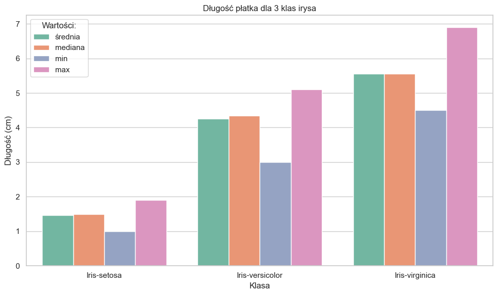

#### Szerokość płatka

|  | klasa (class) | szerokość płatka (petal width) mean | szerokość płatka (petal width) median | szerokość płatka (petal width) min | szerokość płatka (petal width) max |
| --- | --- | --- | --- | --- | --- |
| 0 | Iris-setosa | 0.24 | 0.20 | 0.10 | 0.60 |
| 1 | Iris-versicolor | 1.33 | 1.30 | 1.00 | 1.80 |
| 2 | Iris-virginica | 2.03 | 2.00 | 1.40 | 2.50 |

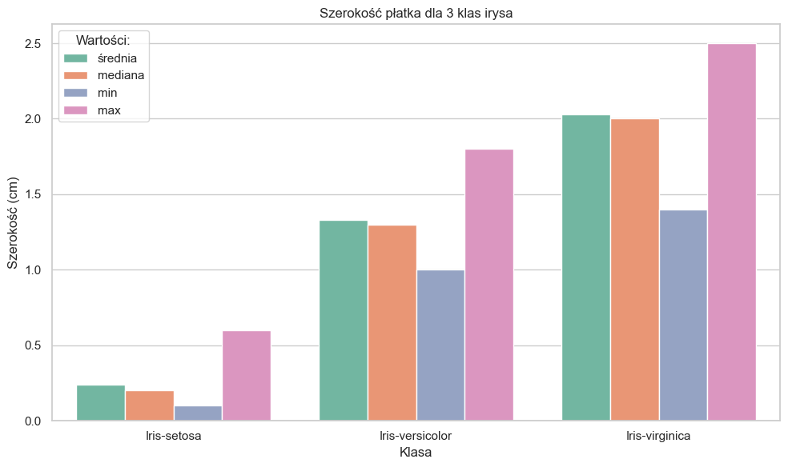

#### Wnioski

1. Irys Setosa - charakteryzuje się najszerszym kielichem oraz drobnymi płatkami.
2. Irys Versicolor - ma średniej wielkości zarówno kielich jak i płatki.
3. Irys Virginica - ma największe płatki oraz najdłuższy kielich.

## Krok 4 - Analiza relacji między zmiennymi

#### Korelacja dla wszystkich Irysów

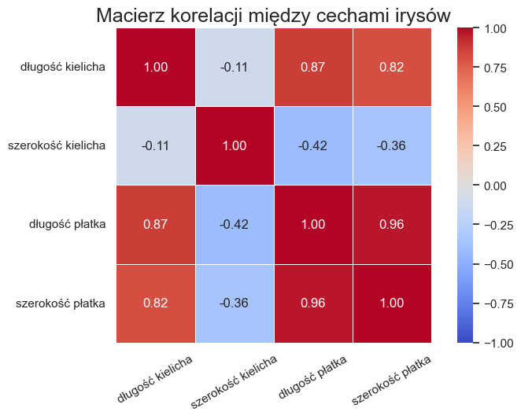

#### Korelacja dla Irysa Setosa

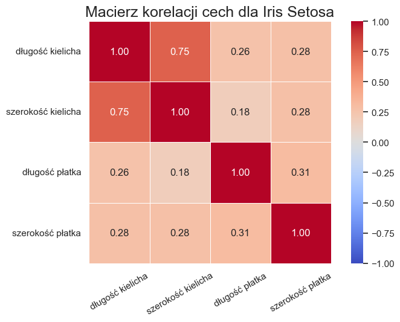

#### Korelacja dla Irysa Versicolor

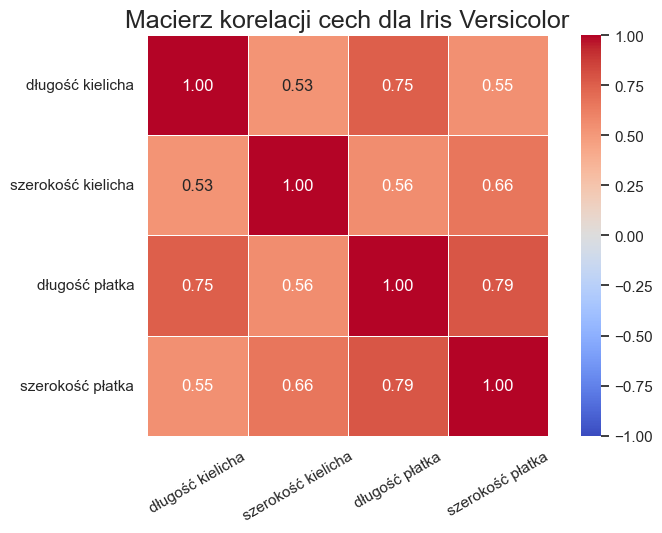

#### Korelacja dla Irysa Virginica

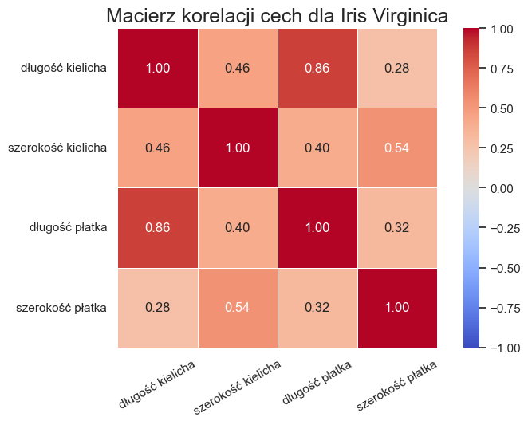

### Wnioski

Wnioski są bardzo ciekawe. Badając korelację między wszystkimi Irysami zauważamy: -

1. największą korelację między długością a szerokością płatka
2. bardzo silną korelację między długością płatka a długością kielicha
3. silną korelację między szerokością płatka a długością kielicha

U samych **Irysów Setosa** natomiast istnieje jedynie silna korelacja między szerokością a długością kielicha.

Dla **Irysów Versicolor** zauważalna korelacja między szerokością a dlugością płatka oraz długością płatka a długością kielicha.

W przypadku **Irys Virginica** jest silna korelacja między długością płatka a długością kielicha.

## Krok 5 - Analiza odstających wartości

#### Irys Setosa

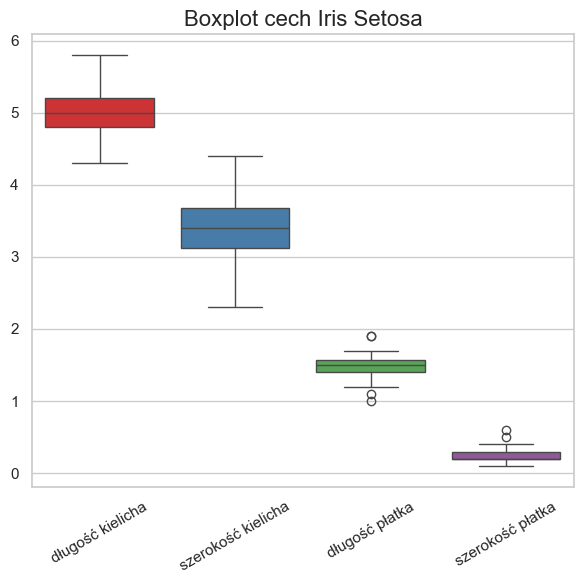

#### Irys Versicolor

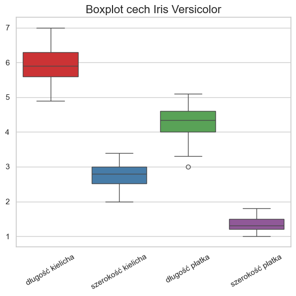

#### Irys Virginica

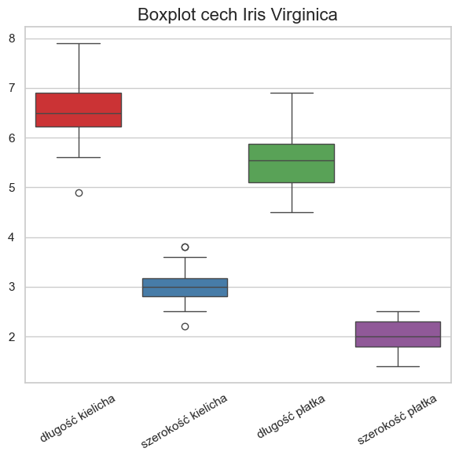

### Wnioski

1. Irys Setosa - 5 wartości odstających - wszystkie dotyczące płatka.
2. Irys Versicolor - 1 wartość odstająca dotycząca długości płatka.
3. Irys Virginica - 3 wartości odstające - wszystkie dotyzące kielicha.

## Podsumowanie

Do analizy danych posłużyły nam 3 gatunki Irysów. Po 50 sztuk dla każdej odmiany. Łącznie 150 kwiatów.

Po analizie danych można dojść do wniosku, że na podstawie gabarytów kielicha oraz płatków możemy rozpoznać odmianę irysa.

**Irys Setosa** - charakteryzuje się najszerszym kielichem oraz drobnymi płatkami.

**Irys Versicolor** - ma średniej wielkości zarówno kielich jak i płatki.

**Irys Virginica** - ma największe płatki oraz najdłuższy kielich.